# Risk Factor Analysis

## Outcome Variable

**Outcome Variable:** y_rate_len

## Predictor Variables

**Intervention Variable:** predfeed3

**Adjustment Set:**

- arm
- sex
- month
- brthmon
- W_mage
- meducyrs
- feducyrs
- hhwealth_quart
- hfoodsec
- W_mhtcm
- W_mwtkg
- W_mbmi
- vagbrth
- W_gagebrth
- W_birthwt
- W_birthlen
- W_nrooms
- W_nchldlt5
- W_parity
- impfloor
- impsan
- safeh20
- delta_W_mage
- delta_meducyrs
- delta_feducyrs
- delta_hhwealth_quart
- delta_hfoodsec
- delta_W_mhtcm
- delta_W_mwtkg
- delta_W_mbmi
- delta_vagbrth
- delta_W_gagebrth
- delta_W_birthwt
- delta_W_birthlen
- delta_W_nrooms
- delta_W_nchldlt5
- delta_W_parity
- delta_impfloor
- delta_impsan
- delta_safeh20

## Stratifying Variables

The analysis was stratified on these variable(s):

- agecat
- studyid
- country

## Data Summary

| agecat | studyid | country | predfeed3 | n_cell | n | outcome_variable |
| --- | --- | --- | --- | --- | --- | --- |
| 0-3 months | ki0047075b-MAL-ED | BANGLADESH | 1 | 193 | 237 | y_rate_len |
| 0-3 months | ki0047075b-MAL-ED | BANGLADESH | 0 | 44 | 237 | y_rate_len |
| 0-3 months | ki0047075b-MAL-ED | BRAZIL | 1 | 73 | 147 | y_rate_len |
| 0-3 months | ki0047075b-MAL-ED | BRAZIL | 0 | 74 | 147 | y_rate_len |
| 0-3 months | ki0047075b-MAL-ED | INDIA | 1 | 113 | 164 | y_rate_len |
| 0-3 months | ki0047075b-MAL-ED | INDIA | 0 | 51 | 164 | y_rate_len |
| 0-3 months | ki0047075b-MAL-ED | NEPAL | 1 | 81 | 153 | y_rate_len |
| 0-3 months | ki0047075b-MAL-ED | NEPAL | 0 | 72 | 153 | y_rate_len |
| 0-3 months | ki0047075b-MAL-ED | PERU | 1 | 168 | 262 | y_rate_len |
| 0-3 months | ki0047075b-MAL-ED | PERU | 0 | 94 | 262 | y_rate_len |
| 0-3 months | ki0047075b-MAL-ED | SOUTH AFRICA | 1 | 58 | 203 | y_rate_len |
| 0-3 months | ki0047075b-MAL-ED | SOUTH AFRICA | 0 | 145 | 203 | y_rate_len |
| 0-3 months | ki0047075b-MAL-ED | TANZANIA, UNITED REPUBLIC OF | 1 | 57 | 197 | y_rate_len |
| 0-3 months | ki0047075b-MAL-ED | TANZANIA, UNITED REPUBLIC OF | 0 | 140 | 197 | y_rate_len |
| 0-3 months | ki1000109-EE | PAKISTAN | 1 | 31 | 31 | y_rate_len |
| 0-3 months | ki1000109-EE | PAKISTAN | 0 | 0 | 31 | y_rate_len |
| 0-3 months | ki1113344-GMS-Nepal | NEPAL | 1 | 378 | 456 | y_rate_len |
| 0-3 months | ki1113344-GMS-Nepal | NEPAL | 0 | 78 | 456 | y_rate_len |
| 0-3 months | kiGH5241-JiVitA-3 | BANGLADESH | 1 | 10705 | 11852 | y_rate_len |
| 0-3 months | kiGH5241-JiVitA-3 | BANGLADESH | 0 | 1147 | 11852 | y_rate_len |
| 0-3 months | kiGH5241-JiVitA-4 | BANGLADESH | 1 | 145 | 160 | y_rate_len |
| 0-3 months | kiGH5241-JiVitA-4 | BANGLADESH | 0 | 15 | 160 | y_rate_len |
| 3-6 months | ki0047075b-MAL-ED | BANGLADESH | 1 | 184 | 225 | y_rate_len |
| 3-6 months | ki0047075b-MAL-ED | BANGLADESH | 0 | 41 | 225 | y_rate_len |
| 3-6 months | ki0047075b-MAL-ED | BRAZIL | 1 | 93 | 186 | y_rate_len |
| 3-6 months | ki0047075b-MAL-ED | BRAZIL | 0 | 93 | 186 | y_rate_len |
| 3-6 months | ki0047075b-MAL-ED | INDIA | 1 | 146 | 206 | y_rate_len |
| 3-6 months | ki0047075b-MAL-ED | INDIA | 0 | 60 | 206 | y_rate_len |
| 3-6 months | ki0047075b-MAL-ED | NEPAL | 1 | 112 | 226 | y_rate_len |
| 3-6 months | ki0047075b-MAL-ED | NEPAL | 0 | 114 | 226 | y_rate_len |

[output cut: 130 more lines]

The following strata were considered:

- agecat: 0-3 months, studyid: ki0047075b-MAL-ED, country: BANGLADESH
- agecat: 0-3 months, studyid: ki0047075b-MAL-ED, country: BRAZIL
- agecat: 0-3 months, studyid: ki0047075b-MAL-ED, country: INDIA
- agecat: 0-3 months, studyid: ki0047075b-MAL-ED, country: NEPAL
- agecat: 0-3 months, studyid: ki0047075b-MAL-ED, country: PERU
- agecat: 0-3 months, studyid: ki0047075b-MAL-ED, country: SOUTH AFRICA
- agecat: 0-3 months, studyid: ki0047075b-MAL-ED, country: TANZANIA, UNITED REPUBLIC OF
- agecat: 0-3 months, studyid: ki1000109-EE, country: PAKISTAN
- agecat: 0-3 months, studyid: ki1113344-GMS-Nepal, country: NEPAL
- agecat: 0-3 months, studyid: kiGH5241-JiVitA-3, country: BANGLADESH
- agecat: 0-3 months, studyid: kiGH5241-JiVitA-4, country: BANGLADESH
- agecat: 12-15 months, studyid: ki0047075b-MAL-ED, country: BANGLADESH
- agecat: 12-15 months, studyid: ki0047075b-MAL-ED, country: BRAZIL
- agecat: 12-15 months, studyid: ki0047075b-MAL-ED, country: INDIA
- agecat: 12-15 months, studyid: ki0047075b-MAL-ED, country: NEPAL
- agecat: 12-15 months, studyid: ki0047075b-MAL-ED, country: PERU
- agecat: 12-15 months, studyid: ki0047075b-MAL-ED, country: SOUTH AFRICA
- agecat: 12-15 months, studyid: ki0047075b-MAL-ED, country: TANZANIA, UNITED REPUBLIC OF
- agecat: 12-15 months, studyid: ki1000109-EE, country: PAKISTAN
- agecat: 12-15 months, studyid: ki1113344-GMS-Nepal, country: NEPAL
- agecat: 12-15 months, studyid: kiGH5241-JiVitA-4, country: BANGLADESH
- agecat: 15-18 months, studyid: ki0047075b-MAL-ED, country: BANGLADESH
- agecat: 15-18 months, studyid: ki0047075b-MAL-ED, country: BRAZIL
- agecat: 15-18 months, studyid: ki0047075b-MAL-ED, country: INDIA
- agecat: 15-18 months, studyid: ki0047075b-MAL-ED, country: NEPAL
- agecat: 15-18 months, studyid: ki0047075b-MAL-ED, country: PERU
- agecat: 15-18 months, studyid: ki0047075b-MAL-ED, country: SOUTH AFRICA
- agecat: 15-18 months, studyid: ki0047075b-MAL-ED, country: TANZANIA, UNITED REPUBLIC OF
- agecat: 15-18 months, studyid: ki1000109-EE, country: PAKISTAN
- agecat: 15-18 months, studyid: ki1113344-GMS-Nepal, country: NEPAL
- agecat: 15-18 months, studyid: kiGH5241-JiVitA-4, country: BANGLADESH
- agecat: 18-21 months, studyid: ki0047075b-MAL-ED, country: BANGLADESH
- agecat: 18-21 months, studyid: ki0047075b-MAL-ED, country: BRAZIL
- agecat: 18-21 months, studyid: ki0047075b-MAL-ED, country: INDIA
- agecat: 18-21 months, studyid: ki0047075b-MAL-ED, country: NEPAL
- agecat: 18-21 months, studyid: ki0047075b-MAL-ED, country: PERU
- agecat: 18-21 months, studyid: ki0047075b-MAL-ED, country: SOUTH AFRICA
- agecat: 18-21 months, studyid: ki0047075b-MAL-ED, country: TANZANIA, UNITED REPUBLIC OF
- agecat: 18-21 months, studyid: ki1000109-EE, country: PAKISTAN
- agecat: 18-21 months, studyid: ki1113344-GMS-Nepal, country: NEPAL
- agecat: 21-24 months, studyid: ki0047075b-MAL-ED, country: BANGLADESH
- agecat: 21-24 months, studyid: ki0047075b-MAL-ED, country: BRAZIL
- agecat: 21-24 months, studyid: ki0047075b-MAL-ED, country: INDIA
- agecat: 21-24 months, studyid: ki0047075b-MAL-ED, country: NEPAL
- agecat: 21-24 months, studyid: ki0047075b-MAL-ED, country: PERU
- agecat: 21-24 months, studyid: ki0047075b-MAL-ED, country: SOUTH AFRICA
- agecat: 21-24 months, studyid: ki0047075b-MAL-ED, country: TANZANIA, UNITED REPUBLIC OF
- agecat: 21-24 months, studyid: ki1000109-EE, country: PAKISTAN
- agecat: 21-24 months, studyid: ki1113344-GMS-Nepal, country: NEPAL
- agecat: 3-6 months, studyid: ki0047075b-MAL-ED, country: BANGLADESH
- agecat: 3-6 months, studyid: ki0047075b-MAL-ED, country: BRAZIL
- agecat: 3-6 months, studyid: ki0047075b-MAL-ED, country: INDIA
- agecat: 3-6 months, studyid: ki0047075b-MAL-ED, country: NEPAL
- agecat: 3-6 months, studyid: ki0047075b-MAL-ED, country: PERU
- agecat: 3-6 months, studyid: ki0047075b-MAL-ED, country: SOUTH AFRICA
- agecat: 3-6 months, studyid: ki0047075b-MAL-ED, country: TANZANIA, UNITED REPUBLIC OF
- agecat: 3-6 months, studyid: ki1000109-EE, country: PAKISTAN
- agecat: 3-6 months, studyid: ki1113344-GMS-Nepal, country: NEPAL
- agecat: 3-6 months, studyid: kiGH5241-JiVitA-3, country: BANGLADESH
- agecat: 3-6 months, studyid: kiGH5241-JiVitA-4, country: BANGLADESH
- agecat: 6-9 months, studyid: ki0047075b-MAL-ED, country: BANGLADESH
- agecat: 6-9 months, studyid: ki0047075b-MAL-ED, country: BRAZIL
- agecat: 6-9 months, studyid: ki0047075b-MAL-ED, country: INDIA
- agecat: 6-9 months, studyid: ki0047075b-MAL-ED, country: NEPAL
- agecat: 6-9 months, studyid: ki0047075b-MAL-ED, country: PERU
- agecat: 6-9 months, studyid: ki0047075b-MAL-ED, country: SOUTH AFRICA
- agecat: 6-9 months, studyid: ki0047075b-MAL-ED, country: TANZANIA, UNITED REPUBLIC OF
- agecat: 6-9 months, studyid: ki1000109-EE, country: PAKISTAN
- agecat: 6-9 months, studyid: ki1113344-GMS-Nepal, country: NEPAL
- agecat: 6-9 months, studyid: kiGH5241-JiVitA-4, country: BANGLADESH
- agecat: 9-12 months, studyid: ki0047075b-MAL-ED, country: BANGLADESH
- agecat: 9-12 months, studyid: ki0047075b-MAL-ED, country: BRAZIL
- agecat: 9-12 months, studyid: ki0047075b-MAL-ED, country: INDIA
- agecat: 9-12 months, studyid: ki0047075b-MAL-ED, country: NEPAL
- agecat: 9-12 months, studyid: ki0047075b-MAL-ED, country: PERU
- agecat: 9-12 months, studyid: ki0047075b-MAL-ED, country: SOUTH AFRICA
- agecat: 9-12 months, studyid: ki0047075b-MAL-ED, country: TANZANIA, UNITED REPUBLIC OF
- agecat: 9-12 months, studyid: ki1000109-EE, country: PAKISTAN
- agecat: 9-12 months, studyid: ki1113344-GMS-Nepal, country: NEPAL
- agecat: 9-12 months, studyid: kiGH5241-JiVitA-4, country: BANGLADESH

### Dropped Strata

- agecat: 0-3 months, studyid: ki1000109-EE, country: PAKISTAN
- agecat: 3-6 months, studyid: ki1000109-EE, country: PAKISTAN
- agecat: 3-6 months, studyid: kiGH5241-JiVitA-4, country: BANGLADESH
- agecat: 6-9 months, studyid: ki1000109-EE, country: PAKISTAN
- agecat: 6-9 months, studyid: kiGH5241-JiVitA-4, country: BANGLADESH
- agecat: 9-12 months, studyid: ki1000109-EE, country: PAKISTAN
- agecat: 12-15 months, studyid: ki1000109-EE, country: PAKISTAN
- agecat: 15-18 months, studyid: ki1000109-EE, country: PAKISTAN
- agecat: 18-21 months, studyid: ki1000109-EE, country: PAKISTAN
- agecat: 21-24 months, studyid: ki1000109-EE, country: PAKISTAN

## Methods Detail

We’re interested in the causal parameters $E[Y_a]$ for all values of $a \in \mathcal{A}$. These parameters represent the mean outcome if, possibly contrary to fact, we intervened to set all units to have $A=a$. Under the randomization and positivity assumptions, these are identified by the statistical parameters $\psi_a=E_W[E_{Y|A,W}(Y|A=a,W)]$. In addition, we’re interested in the mean of $Y$, $E[Y]$ under no intervention (the observed mean). We will estimate these parameters by using SuperLearner to fit the relevant likelihood factors – $E_{Y|A,W}(Y|A=a,W)$ and $p(A=a|W)$, and then updating our likelihood fit using a joint TMLE.

For unadjusted analyses ($W=\{\}$), initial likelihoods were estimated using Lrnr_glm to estimate the simple $E(Y|A)$ and Lrnr_mean to estimate $p(A)$. For adjusted analyses, a small library containing Lrnr_glmnet, Lrnr_xgboost, and Lrnr_mean was used.

Having estimated these parameters, we will then use the delta method to estimate relative risks and attributable risks relative to a prespecified baseline level of $A$.

# Results Detail

## Results Plots

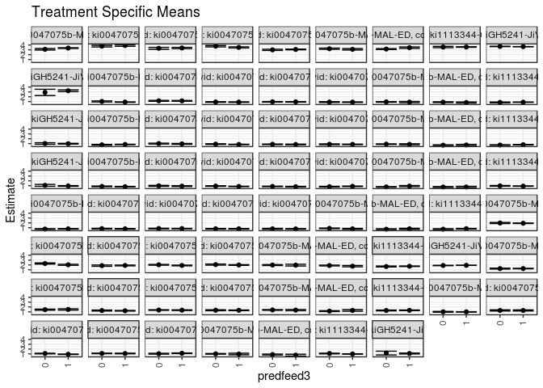

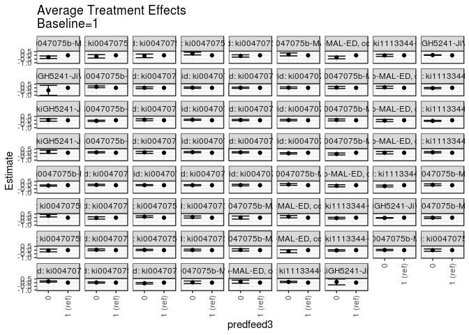

[figure not shown]

## Results Table

### Parameter: TSM

| agecat | studyid | country | intervention_level | baseline_level | estimate | ci_lower | ci_upper |
| --- | --- | --- | --- | --- | --- | --- | --- |
| 0-3 months | ki0047075b-MAL-ED | BANGLADESH | 1 | NA | 3.3680216 | 3.2958544 | 3.4401889 |
| 0-3 months | ki0047075b-MAL-ED | BANGLADESH | 0 | NA | 3.1133857 | 2.9591300 | 3.2676414 |
| 0-3 months | ki0047075b-MAL-ED | BRAZIL | 1 | NA | 3.8988761 | 3.7416247 | 4.0561275 |
| 0-3 months | ki0047075b-MAL-ED | BRAZIL | 0 | NA | 3.7662026 | 3.5954242 | 3.9369810 |
| 0-3 months | ki0047075b-MAL-ED | INDIA | 1 | NA | 3.3879847 | 3.2580591 | 3.5179103 |
| 0-3 months | ki0047075b-MAL-ED | INDIA | 0 | NA | 3.3161522 | 3.1124809 | 3.5198234 |
| 0-3 months | ki0047075b-MAL-ED | NEPAL | 1 | NA | 3.5046219 | 3.3873293 | 3.6219145 |
| 0-3 months | ki0047075b-MAL-ED | NEPAL | 0 | NA | 3.7495042 | 3.6064906 | 3.8925178 |
| 0-3 months | ki0047075b-MAL-ED | PERU | 1 | NA | 3.0845178 | 3.0031884 | 3.1658473 |
| 0-3 months | ki0047075b-MAL-ED | PERU | 0 | NA | 3.0036317 | 2.8767031 | 3.1305604 |
| 0-3 months | ki0047075b-MAL-ED | SOUTH AFRICA | 1 | NA | 3.1078335 | 2.9580105 | 3.2576565 |
| 0-3 months | ki0047075b-MAL-ED | SOUTH AFRICA | 0 | NA | 3.2308680 | 3.1055195 | 3.3562165 |
| 0-3 months | ki0047075b-MAL-ED | TANZANIA, UNITED REPUBLIC OF | 1 | NA | 3.4572733 | 3.3047358 | 3.6098109 |
| 0-3 months | ki0047075b-MAL-ED | TANZANIA, UNITED REPUBLIC OF | 0 | NA | 3.1668813 | 3.0691388 | 3.2646237 |
| 0-3 months | ki1113344-GMS-Nepal | NEPAL | 1 | NA | 3.5854343 | 3.5266562 | 3.6442125 |
| 0-3 months | ki1113344-GMS-Nepal | NEPAL | 0 | NA | 3.5797233 | 3.4397411 | 3.7197055 |
| 0-3 months | kiGH5241-JiVitA-3 | BANGLADESH | 1 | NA | 3.6635795 | 3.6504914 | 3.6766675 |
| 0-3 months | kiGH5241-JiVitA-3 | BANGLADESH | 0 | NA | 3.7025990 | 3.6693234 | 3.7358747 |
| 0-3 months | kiGH5241-JiVitA-4 | BANGLADESH | 1 | NA | 3.2389031 | 3.0593354 | 3.4184707 |
| 0-3 months | kiGH5241-JiVitA-4 | BANGLADESH | 0 | NA | 2.8941755 | 2.2478001 | 3.5405510 |
| 3-6 months | ki0047075b-MAL-ED | BANGLADESH | 1 | NA | 1.9227281 | 1.8670493 | 1.9784069 |
| 3-6 months | ki0047075b-MAL-ED | BANGLADESH | 0 | NA | 1.9783824 | 1.8669562 | 2.0898085 |
| 3-6 months | ki0047075b-MAL-ED | BRAZIL | 1 | NA | 2.0301156 | 1.9190367 | 2.1411945 |
| 3-6 months | ki0047075b-MAL-ED | BRAZIL | 0 | NA | 2.2958881 | 2.1759173 | 2.4158590 |
| 3-6 months | ki0047075b-MAL-ED | INDIA | 1 | NA | 1.8915866 | 1.8102240 | 1.9729492 |
| 3-6 months | ki0047075b-MAL-ED | INDIA | 0 | NA | 1.8556885 | 1.7211973 | 1.9901797 |
| 3-6 months | ki0047075b-MAL-ED | NEPAL | 1 | NA | 1.8912609 | 1.8145015 | 1.9680202 |
| 3-6 months | ki0047075b-MAL-ED | NEPAL | 0 | NA | 2.0303476 | 1.9475668 | 2.1131285 |
| 3-6 months | ki0047075b-MAL-ED | PERU | 1 | NA | 1.9856878 | 1.9064063 | 2.0649693 |
| 3-6 months | ki0047075b-MAL-ED | PERU | 0 | NA | 2.0712618 | 1.9530262 | 2.1894973 |

[output cut: 110 more lines]

### Parameter: E(Y)

| agecat | studyid | country | intervention_level | baseline_level | estimate | ci_lower | ci_upper |
| --- | --- | --- | --- | --- | --- | --- | --- |
| 0-3 months | ki0047075b-MAL-ED | BANGLADESH | NA | NA | 3.3300100 | 3.2632400 | 3.3967800 |
| 0-3 months | ki0047075b-MAL-ED | BRAZIL | NA | NA | 3.8333086 | 3.7172183 | 3.9493989 |
| 0-3 months | ki0047075b-MAL-ED | INDIA | NA | NA | 3.3581259 | 3.2511263 | 3.4651254 |
| 0-3 months | ki0047075b-MAL-ED | NEPAL | NA | NA | 3.6149130 | 3.5218465 | 3.7079794 |
| 0-3 months | ki0047075b-MAL-ED | PERU | NA | NA | 3.0514630 | 2.9842485 | 3.1186774 |
| 0-3 months | ki0047075b-MAL-ED | SOUTH AFRICA | NA | NA | 3.1964081 | 3.0976125 | 3.2952037 |
| 0-3 months | ki0047075b-MAL-ED | TANZANIA, UNITED REPUBLIC OF | NA | NA | 3.2460048 | 3.1627741 | 3.3292354 |
| 0-3 months | ki1113344-GMS-Nepal | NEPAL | NA | NA | 3.5832888 | 3.5291425 | 3.6374351 |
| 0-3 months | kiGH5241-JiVitA-3 | BANGLADESH | NA | NA | 3.6671582 | 3.6544756 | 3.6798407 |
| 0-3 months | kiGH5241-JiVitA-4 | BANGLADESH | NA | NA | 3.2111724 | 3.0390342 | 3.3833107 |
| 3-6 months | ki0047075b-MAL-ED | BANGLADESH | NA | NA | 1.9360220 | 1.8863911 | 1.9856528 |
| 3-6 months | ki0047075b-MAL-ED | BRAZIL | NA | NA | 2.1610058 | 2.0768189 | 2.2451928 |
| 3-6 months | ki0047075b-MAL-ED | INDIA | NA | NA | 1.8774058 | 1.8092128 | 1.9455987 |
| 3-6 months | ki0047075b-MAL-ED | NEPAL | NA | NA | 1.9604886 | 1.9037186 | 2.0172585 |
| 3-6 months | ki0047075b-MAL-ED | PERU | NA | NA | 2.0146923 | 1.9480408 | 2.0813438 |
| 3-6 months | ki0047075b-MAL-ED | SOUTH AFRICA | NA | NA | 1.9673270 | 1.8846989 | 2.0499551 |
| 3-6 months | ki0047075b-MAL-ED | TANZANIA, UNITED REPUBLIC OF | NA | NA | 1.8384078 | 1.7678309 | 1.9089846 |
| 3-6 months | ki1113344-GMS-Nepal | NEPAL | NA | NA | 1.7175472 | 1.6762113 | 1.7588831 |
| 3-6 months | kiGH5241-JiVitA-3 | BANGLADESH | NA | NA | 1.9166214 | 1.9029983 | 1.9302445 |
| 6-9 months | ki0047075b-MAL-ED | BANGLADESH | NA | NA | 1.2426951 | 1.2021480 | 1.2832422 |
| 6-9 months | ki0047075b-MAL-ED | BRAZIL | NA | NA | 1.4793615 | 1.3932814 | 1.5654415 |
| 6-9 months | ki0047075b-MAL-ED | INDIA | NA | NA | 1.2410939 | 1.1870908 | 1.2950970 |
| 6-9 months | ki0047075b-MAL-ED | NEPAL | NA | NA | 1.3593977 | 1.3145109 | 1.4042846 |
| 6-9 months | ki0047075b-MAL-ED | PERU | NA | NA | 1.3181643 | 1.2633979 | 1.3729307 |
| 6-9 months | ki0047075b-MAL-ED | SOUTH AFRICA | NA | NA | 1.3866251 | 1.3204306 | 1.4528196 |
| 6-9 months | ki0047075b-MAL-ED | TANZANIA, UNITED REPUBLIC OF | NA | NA | 1.1862735 | 1.1092792 | 1.2632679 |
| 6-9 months | ki1113344-GMS-Nepal | NEPAL | NA | NA | 1.3149164 | 1.2666599 | 1.3631729 |
| 9-12 months | ki0047075b-MAL-ED | BANGLADESH | NA | NA | 0.9927203 | 0.9534705 | 1.0319702 |
| 9-12 months | ki0047075b-MAL-ED | BRAZIL | NA | NA | 1.2871495 | 1.2069822 | 1.3673169 |
| 9-12 months | ki0047075b-MAL-ED | INDIA | NA | NA | 0.9664571 | 0.9272553 | 1.0056589 |
| 9-12 months | ki0047075b-MAL-ED | NEPAL | NA | NA | 1.0863279 | 1.0443920 | 1.1282637 |
| 9-12 months | ki0047075b-MAL-ED | PERU | NA | NA | 1.0996556 | 1.0484043 | 1.1509069 |
| 9-12 months | ki0047075b-MAL-ED | SOUTH AFRICA | NA | NA | 0.9974431 | 0.9321487 | 1.0627375 |
| 9-12 months | ki0047075b-MAL-ED | TANZANIA, UNITED REPUBLIC OF | NA | NA | 0.8135761 | 0.7280408 | 0.8991114 |
| 9-12 months | ki1113344-GMS-Nepal | NEPAL | NA | NA | 0.9981577 | 0.9587526 | 1.0375629 |
| 9-12 months | kiGH5241-JiVitA-4 | BANGLADESH | NA | NA | 1.0827638 | 1.0008916 | 1.1646360 |
| 12-15 months | ki0047075b-MAL-ED | BANGLADESH | NA | NA | 0.9168218 | 0.8756400 | 0.9580036 |
| 12-15 months | ki0047075b-MAL-ED | BRAZIL | NA | NA | 1.1479969 | 1.0880713 | 1.2079226 |
| 12-15 months | ki0047075b-MAL-ED | INDIA | NA | NA | 0.9027484 | 0.8605827 | 0.9449141 |
| 12-15 months | ki0047075b-MAL-ED | NEPAL | NA | NA | 0.9510803 | 0.9108264 | 0.9913342 |
| 12-15 months | ki0047075b-MAL-ED | PERU | NA | NA | 0.8899324 | 0.8436019 | 0.9362629 |
| 12-15 months | ki0047075b-MAL-ED | SOUTH AFRICA | NA | NA | 0.9200282 | 0.8606688 | 0.9793876 |
| 12-15 months | ki0047075b-MAL-ED | TANZANIA, UNITED REPUBLIC OF | NA | NA | 0.8603058 | 0.7910045 | 0.9296071 |
| 12-15 months | ki1113344-GMS-Nepal | NEPAL | NA | NA | 0.8703223 | 0.8418462 | 0.8987983 |
| 12-15 months | kiGH5241-JiVitA-4 | BANGLADESH | NA | NA | 0.9942404 | 0.9259295 | 1.0625513 |
| 15-18 months | ki0047075b-MAL-ED | BANGLADESH | NA | NA | 0.8229575 | 0.7855057 | 0.8604093 |
| 15-18 months | ki0047075b-MAL-ED | BRAZIL | NA | NA | 0.9818884 | 0.9203285 | 1.0434482 |
| 15-18 months | ki0047075b-MAL-ED | INDIA | NA | NA | 0.8524809 | 0.8141426 | 0.8908193 |
| 15-18 months | ki0047075b-MAL-ED | NEPAL | NA | NA | 0.8379671 | 0.7952249 | 0.8807093 |
| 15-18 months | ki0047075b-MAL-ED | PERU | NA | NA | 0.8524194 | 0.8100116 | 0.8948273 |
| 15-18 months | ki0047075b-MAL-ED | SOUTH AFRICA | NA | NA | 0.8824996 | 0.8291590 | 0.9358403 |
| 15-18 months | ki0047075b-MAL-ED | TANZANIA, UNITED REPUBLIC OF | NA | NA | 0.6765672 | 0.6111365 | 0.7419980 |
| 15-18 months | ki1113344-GMS-Nepal | NEPAL | NA | NA | 0.7714871 | 0.7347479 | 0.8082263 |
| 15-18 months | kiGH5241-JiVitA-4 | BANGLADESH | NA | NA | 0.9624250 | 0.8894872 | 1.0353628 |
| 18-21 months | ki0047075b-MAL-ED | BANGLADESH | NA | NA | 0.8119236 | 0.7768456 | 0.8470016 |
| 18-21 months | ki0047075b-MAL-ED | BRAZIL | NA | NA | 0.9218418 | 0.8499673 | 0.9937164 |
| 18-21 months | ki0047075b-MAL-ED | INDIA | NA | NA | 0.8718128 | 0.8338464 | 0.9097793 |
| 18-21 months | ki0047075b-MAL-ED | NEPAL | NA | NA | 0.8188898 | 0.7796721 | 0.8581075 |
| 18-21 months | ki0047075b-MAL-ED | PERU | NA | NA | 0.8436364 | 0.7988407 | 0.8884321 |
| 18-21 months | ki0047075b-MAL-ED | SOUTH AFRICA | NA | NA | 0.7825058 | 0.7256746 | 0.8393371 |
| 18-21 months | ki0047075b-MAL-ED | TANZANIA, UNITED REPUBLIC OF | NA | NA | 0.7427314 | 0.6697155 | 0.8157473 |
| 18-21 months | ki1113344-GMS-Nepal | NEPAL | NA | NA | 0.9164610 | 0.8758269 | 0.9570951 |
| 21-24 months | ki0047075b-MAL-ED | BANGLADESH | NA | NA | 0.7650086 | 0.7291204 | 0.8008969 |
| 21-24 months | ki0047075b-MAL-ED | BRAZIL | NA | NA | 0.7910255 | 0.7450530 | 0.8369980 |
| 21-24 months | ki0047075b-MAL-ED | INDIA | NA | NA | 0.8277879 | 0.7947160 | 0.8608598 |
| 21-24 months | ki0047075b-MAL-ED | NEPAL | NA | NA | 0.7874809 | 0.7457868 | 0.8291749 |
| 21-24 months | ki0047075b-MAL-ED | PERU | NA | NA | 0.7633557 | 0.7160871 | 0.8106244 |
| 21-24 months | ki0047075b-MAL-ED | SOUTH AFRICA | NA | NA | 0.8419384 | 0.7887410 | 0.8951359 |
| 21-24 months | ki0047075b-MAL-ED | TANZANIA, UNITED REPUBLIC OF | NA | NA | 0.7195266 | 0.6482537 | 0.7907995 |
| 21-24 months | ki1113344-GMS-Nepal | NEPAL | NA | NA | 0.7890401 | 0.7373935 | 0.8406867 |

### Parameter: ATE

| agecat | studyid | country | intervention_level | baseline_level | estimate | ci_lower | ci_upper |
| --- | --- | --- | --- | --- | --- | --- | --- |
| 0-3 months | ki0047075b-MAL-ED | BANGLADESH | 1 | 1 | 0.0000000 | 0.0000000 | 0.0000000 |
| 0-3 months | ki0047075b-MAL-ED | BANGLADESH | 0 | 1 | -0.2546360 | -0.4247575 | -0.0845144 |
| 0-3 months | ki0047075b-MAL-ED | BRAZIL | 1 | 1 | 0.0000000 | 0.0000000 | 0.0000000 |
| 0-3 months | ki0047075b-MAL-ED | BRAZIL | 0 | 1 | -0.1326735 | -0.3655173 | 0.1001703 |
| 0-3 months | ki0047075b-MAL-ED | INDIA | 1 | 1 | 0.0000000 | 0.0000000 | 0.0000000 |
| 0-3 months | ki0047075b-MAL-ED | INDIA | 0 | 1 | -0.0718325 | -0.3155366 | 0.1718716 |
| 0-3 months | ki0047075b-MAL-ED | NEPAL | 1 | 1 | 0.0000000 | 0.0000000 | 0.0000000 |
| 0-3 months | ki0047075b-MAL-ED | NEPAL | 0 | 1 | 0.2448823 | 0.0592937 | 0.4304709 |
| 0-3 months | ki0047075b-MAL-ED | PERU | 1 | 1 | 0.0000000 | 0.0000000 | 0.0000000 |
| 0-3 months | ki0047075b-MAL-ED | PERU | 0 | 1 | -0.0808861 | -0.2353399 | 0.0735677 |
| 0-3 months | ki0047075b-MAL-ED | SOUTH AFRICA | 1 | 1 | 0.0000000 | 0.0000000 | 0.0000000 |
| 0-3 months | ki0047075b-MAL-ED | SOUTH AFRICA | 0 | 1 | 0.1230345 | -0.0725740 | 0.3186430 |
| 0-3 months | ki0047075b-MAL-ED | TANZANIA, UNITED REPUBLIC OF | 1 | 1 | 0.0000000 | 0.0000000 | 0.0000000 |
| 0-3 months | ki0047075b-MAL-ED | TANZANIA, UNITED REPUBLIC OF | 0 | 1 | -0.2903921 | -0.4717339 | -0.1090503 |
| 0-3 months | ki1113344-GMS-Nepal | NEPAL | 1 | 1 | 0.0000000 | 0.0000000 | 0.0000000 |
| 0-3 months | ki1113344-GMS-Nepal | NEPAL | 0 | 1 | -0.0057111 | -0.1575796 | 0.1461575 |
| 0-3 months | kiGH5241-JiVitA-3 | BANGLADESH | 1 | 1 | 0.0000000 | 0.0000000 | 0.0000000 |
| 0-3 months | kiGH5241-JiVitA-3 | BANGLADESH | 0 | 1 | 0.0390196 | 0.0050062 | 0.0730329 |
| 0-3 months | kiGH5241-JiVitA-4 | BANGLADESH | 1 | 1 | 0.0000000 | 0.0000000 | 0.0000000 |
| 0-3 months | kiGH5241-JiVitA-4 | BANGLADESH | 0 | 1 | -0.3447275 | -1.0146598 | 0.3252048 |
| 3-6 months | ki0047075b-MAL-ED | BANGLADESH | 1 | 1 | 0.0000000 | 0.0000000 | 0.0000000 |
| 3-6 months | ki0047075b-MAL-ED | BANGLADESH | 0 | 1 | 0.0556543 | -0.0695526 | 0.1808612 |
| 3-6 months | ki0047075b-MAL-ED | BRAZIL | 1 | 1 | 0.0000000 | 0.0000000 | 0.0000000 |
| 3-6 months | ki0047075b-MAL-ED | BRAZIL | 0 | 1 | 0.2657725 | 0.1018417 | 0.4297033 |
| 3-6 months | ki0047075b-MAL-ED | INDIA | 1 | 1 | 0.0000000 | 0.0000000 | 0.0000000 |
| 3-6 months | ki0047075b-MAL-ED | INDIA | 0 | 1 | -0.0358981 | -0.1944052 | 0.1226090 |
| 3-6 months | ki0047075b-MAL-ED | NEPAL | 1 | 1 | 0.0000000 | 0.0000000 | 0.0000000 |
| 3-6 months | ki0047075b-MAL-ED | NEPAL | 0 | 1 | 0.1390867 | 0.0267127 | 0.2514607 |
| 3-6 months | ki0047075b-MAL-ED | PERU | 1 | 1 | 0.0000000 | 0.0000000 | 0.0000000 |
| 3-6 months | ki0047075b-MAL-ED | PERU | 0 | 1 | 0.0855739 | -0.0569757 | 0.2281236 |

[output cut: 110 more lines]

### Parameter: PAR

| agecat | studyid | country | intervention_level | baseline_level | estimate | ci_lower | ci_upper |
| --- | --- | --- | --- | --- | --- | --- | --- |
| 0-3 months | ki0047075b-MAL-ED | BANGLADESH | 1 | NA | -0.0380116 | -0.0715166 | -0.0045066 |
| 0-3 months | ki0047075b-MAL-ED | BRAZIL | 1 | NA | -0.0655675 | -0.1833767 | 0.0522417 |
| 0-3 months | ki0047075b-MAL-ED | INDIA | 1 | NA | -0.0298588 | -0.1019248 | 0.0422071 |
| 0-3 months | ki0047075b-MAL-ED | NEPAL | 1 | NA | 0.1102911 | 0.0215257 | 0.1990564 |
| 0-3 months | ki0047075b-MAL-ED | PERU | 1 | NA | -0.0330549 | -0.0887804 | 0.0226706 |
| 0-3 months | ki0047075b-MAL-ED | SOUTH AFRICA | 1 | NA | 0.0885746 | -0.0521521 | 0.2293014 |
| 0-3 months | ki0047075b-MAL-ED | TANZANIA, UNITED REPUBLIC OF | 1 | NA | -0.2112685 | -0.3421840 | -0.0803531 |
| 0-3 months | ki1113344-GMS-Nepal | NEPAL | 1 | NA | -0.0021455 | -0.0280331 | 0.0237420 |
| 0-3 months | kiGH5241-JiVitA-3 | BANGLADESH | 1 | NA | 0.0035787 | 0.0002782 | 0.0068792 |
| 0-3 months | kiGH5241-JiVitA-4 | BANGLADESH | 1 | NA | -0.0277306 | -0.0843611 | 0.0288998 |
| 3-6 months | ki0047075b-MAL-ED | BANGLADESH | 1 | NA | 0.0132939 | -0.0097410 | 0.0363288 |
| 3-6 months | ki0047075b-MAL-ED | BRAZIL | 1 | NA | 0.1308902 | 0.0464842 | 0.2152963 |
| 3-6 months | ki0047075b-MAL-ED | INDIA | 1 | NA | -0.0141808 | -0.0593618 | 0.0310002 |
| 3-6 months | ki0047075b-MAL-ED | NEPAL | 1 | NA | 0.0692277 | 0.0112771 | 0.1271783 |
| 3-6 months | ki0047075b-MAL-ED | PERU | 1 | NA | 0.0290045 | -0.0197970 | 0.0778059 |
| 3-6 months | ki0047075b-MAL-ED | SOUTH AFRICA | 1 | NA | 0.0056880 | -0.1531320 | 0.1645080 |
| 3-6 months | ki0047075b-MAL-ED | TANZANIA, UNITED REPUBLIC OF | 1 | NA | 0.0941915 | -0.0178235 | 0.2062064 |
| 3-6 months | ki1113344-GMS-Nepal | NEPAL | 1 | NA | -0.0079090 | -0.0256739 | 0.0098560 |
| 3-6 months | kiGH5241-JiVitA-3 | BANGLADESH | 1 | NA | -0.0028070 | -0.0066804 | 0.0010665 |
| 6-9 months | ki0047075b-MAL-ED | BANGLADESH | 1 | NA | -0.0042744 | -0.0246728 | 0.0161241 |
| 6-9 months | ki0047075b-MAL-ED | BRAZIL | 1 | NA | -0.0163207 | -0.1083939 | 0.0757525 |
| 6-9 months | ki0047075b-MAL-ED | INDIA | 1 | NA | 0.0196328 | -0.0170575 | 0.0563231 |
| 6-9 months | ki0047075b-MAL-ED | NEPAL | 1 | NA | 0.0146264 | -0.0302364 | 0.0594891 |
| 6-9 months | ki0047075b-MAL-ED | PERU | 1 | NA | 0.0027477 | -0.0371739 | 0.0426692 |
| 6-9 months | ki0047075b-MAL-ED | SOUTH AFRICA | 1 | NA | 0.0236152 | -0.0875624 | 0.1347927 |
| 6-9 months | ki0047075b-MAL-ED | TANZANIA, UNITED REPUBLIC OF | 1 | NA | -0.1103253 | -0.2479782 | 0.0273277 |
| 6-9 months | ki1113344-GMS-Nepal | NEPAL | 1 | NA | -0.0034291 | -0.0209561 | 0.0140980 |
| 9-12 months | ki0047075b-MAL-ED | BANGLADESH | 1 | NA | 0.0022871 | -0.0139076 | 0.0184818 |
| 9-12 months | ki0047075b-MAL-ED | BRAZIL | 1 | NA | -0.0023483 | -0.0825633 | 0.0778668 |
| 9-12 months | ki0047075b-MAL-ED | INDIA | 1 | NA | 0.0466299 | 0.0205910 | 0.0726689 |
| 9-12 months | ki0047075b-MAL-ED | NEPAL | 1 | NA | 0.0065411 | -0.0368002 | 0.0498824 |
| 9-12 months | ki0047075b-MAL-ED | PERU | 1 | NA | -0.0246864 | -0.0604863 | 0.0111136 |
| 9-12 months | ki0047075b-MAL-ED | SOUTH AFRICA | 1 | NA | 0.0278901 | -0.1061336 | 0.1619138 |
| 9-12 months | ki0047075b-MAL-ED | TANZANIA, UNITED REPUBLIC OF | 1 | NA | 0.0705175 | -0.0774023 | 0.2184373 |
| 9-12 months | ki1113344-GMS-Nepal | NEPAL | 1 | NA | 0.0170468 | 0.0024463 | 0.0316472 |
| 9-12 months | kiGH5241-JiVitA-4 | BANGLADESH | 1 | NA | 0.0047432 | -0.0301581 | 0.0396445 |
| 12-15 months | ki0047075b-MAL-ED | BANGLADESH | 1 | NA | 0.0217034 | -0.0011842 | 0.0445910 |
| 12-15 months | ki0047075b-MAL-ED | BRAZIL | 1 | NA | -0.0008542 | -0.0592638 | 0.0575554 |
| 12-15 months | ki0047075b-MAL-ED | INDIA | 1 | NA | 0.0072414 | -0.0205146 | 0.0349973 |
| 12-15 months | ki0047075b-MAL-ED | NEPAL | 1 | NA | 0.0055050 | -0.0356939 | 0.0467040 |
| 12-15 months | ki0047075b-MAL-ED | PERU | 1 | NA | 0.0076573 | -0.0265740 | 0.0418887 |
| 12-15 months | ki0047075b-MAL-ED | SOUTH AFRICA | 1 | NA | 0.0268661 | -0.0832646 | 0.1369968 |
| 12-15 months | ki0047075b-MAL-ED | TANZANIA, UNITED REPUBLIC OF | 1 | NA | 0.0498054 | -0.0557054 | 0.1553162 |
| 12-15 months | ki1113344-GMS-Nepal | NEPAL | 1 | NA | -0.0026545 | -0.0161435 | 0.0108346 |
| 12-15 months | kiGH5241-JiVitA-4 | BANGLADESH | 1 | NA | 0.0106903 | -0.0127425 | 0.0341231 |
| 15-18 months | ki0047075b-MAL-ED | BANGLADESH | 1 | NA | -0.0116665 | -0.0284414 | 0.0051084 |
| 15-18 months | ki0047075b-MAL-ED | BRAZIL | 1 | NA | 0.0364088 | -0.0251464 | 0.0979639 |
| 15-18 months | ki0047075b-MAL-ED | INDIA | 1 | NA | 0.0243803 | -0.0027413 | 0.0515019 |
| 15-18 months | ki0047075b-MAL-ED | NEPAL | 1 | NA | 0.0093814 | -0.0338955 | 0.0526583 |
| 15-18 months | ki0047075b-MAL-ED | PERU | 1 | NA | 0.0085656 | -0.0233707 | 0.0405019 |
| 15-18 months | ki0047075b-MAL-ED | SOUTH AFRICA | 1 | NA | 0.0322338 | -0.0693184 | 0.1337860 |
| 15-18 months | ki0047075b-MAL-ED | TANZANIA, UNITED REPUBLIC OF | 1 | NA | -0.0389825 | -0.1446955 | 0.0667304 |
| 15-18 months | ki1113344-GMS-Nepal | NEPAL | 1 | NA | -0.0138609 | -0.0254707 | -0.0022511 |
| 15-18 months | kiGH5241-JiVitA-4 | BANGLADESH | 1 | NA | 0.0184892 | -0.0066893 | 0.0436676 |
| 18-21 months | ki0047075b-MAL-ED | BANGLADESH | 1 | NA | 0.0090618 | -0.0055235 | 0.0236470 |
| 18-21 months | ki0047075b-MAL-ED | BRAZIL | 1 | NA | 0.0122737 | -0.0581517 | 0.0826992 |
| 18-21 months | ki0047075b-MAL-ED | INDIA | 1 | NA | 0.0272460 | -0.0003862 | 0.0548782 |
| 18-21 months | ki0047075b-MAL-ED | NEPAL | 1 | NA | 0.0256397 | -0.0146832 | 0.0659626 |
| 18-21 months | ki0047075b-MAL-ED | PERU | 1 | NA | -0.0258028 | -0.0562265 | 0.0046208 |
| 18-21 months | ki0047075b-MAL-ED | SOUTH AFRICA | 1 | NA | -0.1283006 | -0.2261469 | -0.0304543 |
| 18-21 months | ki0047075b-MAL-ED | TANZANIA, UNITED REPUBLIC OF | 1 | NA | 0.0207504 | -0.0971497 | 0.1386505 |
| 18-21 months | ki1113344-GMS-Nepal | NEPAL | 1 | NA | 0.0058595 | -0.0073676 | 0.0190866 |
| 21-24 months | ki0047075b-MAL-ED | BANGLADESH | 1 | NA | -0.0076474 | -0.0224780 | 0.0071832 |
| 21-24 months | ki0047075b-MAL-ED | BRAZIL | 1 | NA | 0.0116499 | -0.0330045 | 0.0563043 |
| 21-24 months | ki0047075b-MAL-ED | INDIA | 1 | NA | 0.0034946 | -0.0189769 | 0.0259661 |
| 21-24 months | ki0047075b-MAL-ED | NEPAL | 1 | NA | 0.0015472 | -0.0398748 | 0.0429692 |
| 21-24 months | ki0047075b-MAL-ED | PERU | 1 | NA | 0.0053282 | -0.0295954 | 0.0402519 |
| 21-24 months | ki0047075b-MAL-ED | SOUTH AFRICA | 1 | NA | 0.0707057 | -0.0180112 | 0.1594227 |
| 21-24 months | ki0047075b-MAL-ED | TANZANIA, UNITED REPUBLIC OF | 1 | NA | -0.0562688 | -0.1554300 | 0.0428925 |
| 21-24 months | ki1113344-GMS-Nepal | NEPAL | 1 | NA | -0.0160398 | -0.0343784 | 0.0022988 |